# Exploratory Data Analysis for Machine Learning

## Module 5: Final Project

Telco Customer Churn Data Analysis

Dataset source: https://community.ibm.com/community/user/blogs/steven-macko/2019/07/11/telco-customer-churn-1113

A fictional telco company which provided phone and internet services has a dataset of 7043 customers. It contains information of customers such as senior status, gender, and other features. The target of this dataset is the churn outcome of each customer, saying whether they churned or not.

In this project, we will import the data, handle any missing data, perform EDA, and hypothesis testing.

### Package Loading and Data Import

```python
import pandas as pd
import numpy as np
import seaborn as sns
import matplotlib.pyplot as plt
from matplotlib.ticker import MultipleLocator

import scipy.stats as stats
from scipy.stats import chi2_contingency
from scipy.stats import norm
```

```python
churn_data = pd.read_csv("data/WA_Fn-UseC_-Telco-Customer-Churn.csv")
churn_data.head()
```

|  | customerID | gender | SeniorCitizen | Partner | Dependents | tenure | PhoneService | MultipleLines | InternetService | OnlineSecurity | ... | DeviceProtection | TechSupport | StreamingTV | StreamingMovies | Contract | PaperlessBilling | PaymentMethod | MonthlyCharges | TotalCharges | Churn |
| --- | --- | --- | --- | --- | --- | --- | --- | --- | --- | --- | --- | --- | --- | --- | --- | --- | --- | --- | --- | --- | --- |
| 0 | 7590-VHVEG | Female | 0 | Yes | No | 1 | No | No phone service | DSL | No | ... | No | No | No | No | Month-to-month | Yes | Electronic check | 29.85 | 29.85 | No |
| 1 | 5575-GNVDE | Male | 0 | No | No | 34 | Yes | No | DSL | Yes | ... | Yes | No | No | No | One year | No | Mailed check | 56.95 | 1889.5 | No |
| 2 | 3668-QPYBK | Male | 0 | No | No | 2 | Yes | No | DSL | Yes | ... | No | No | No | No | Month-to-month | Yes | Mailed check | 53.85 | 108.15 | Yes |
| 3 | 7795-CFOCW | Male | 0 | No | No | 45 | No | No phone service | DSL | Yes | ... | Yes | Yes | No | No | One year | No | Bank transfer (automatic) | 42.30 | 1840.75 | No |
| 4 | 9237-HQITU | Female | 0 | No | No | 2 | Yes | No | Fiber optic | No | ... | No | No | No | No | Month-to-month | Yes | Electronic check | 70.70 | 151.65 | Yes |

5 rows × 21 columns

### Overview and QC

```python
churn_data.info()
```

```
<class 'pandas.core.frame.DataFrame'>
RangeIndex: 7043 entries, 0 to 7042
Data columns (total 21 columns):
 #   Column            Non-Null Count  Dtype
---  ------            --------------  -----
 0   customerID        7043 non-null   object
 1   gender            7043 non-null   object
 2   SeniorCitizen     7043 non-null   int64
 3   Partner           7043 non-null   object
 4   Dependents        7043 non-null   object
 5   tenure            7043 non-null   int64
 6   PhoneService      7043 non-null   object
 7   MultipleLines     7043 non-null   object
 8   InternetService   7043 non-null   object
 9   OnlineSecurity    7043 non-null   object
 10  OnlineBackup      7043 non-null   object
 11  DeviceProtection  7043 non-null   object
 12  TechSupport       7043 non-null   object
 13  StreamingTV       7043 non-null   object
 14  StreamingMovies   7043 non-null   object
 15  Contract          7043 non-null   object
 16  PaperlessBilling  7043 non-null   object
 17  PaymentMethod     7043 non-null   object
 18  MonthlyCharges    7043 non-null   float64
 19  TotalCharges      7043 non-null   object
 20  Churn             7043 non-null   object
dtypes: float64(1), int64(2), object(18)
memory usage: 1.1+ MB
```

```python
churn_data.describe()
```

|  | SeniorCitizen | tenure | MonthlyCharges |
| --- | --- | --- | --- |
| count | 7043.000000 | 7043.000000 | 7043.000000 |
| mean | 0.162147 | 32.371149 | 64.761692 |
| std | 0.368612 | 24.559481 | 30.090047 |
| min | 0.000000 | 0.000000 | 18.250000 |
| 25% | 0.000000 | 9.000000 | 35.500000 |
| 50% | 0.000000 | 29.000000 | 70.350000 |
| 75% | 0.000000 | 55.000000 | 89.850000 |
| max | 1.000000 | 72.000000 | 118.750000 |

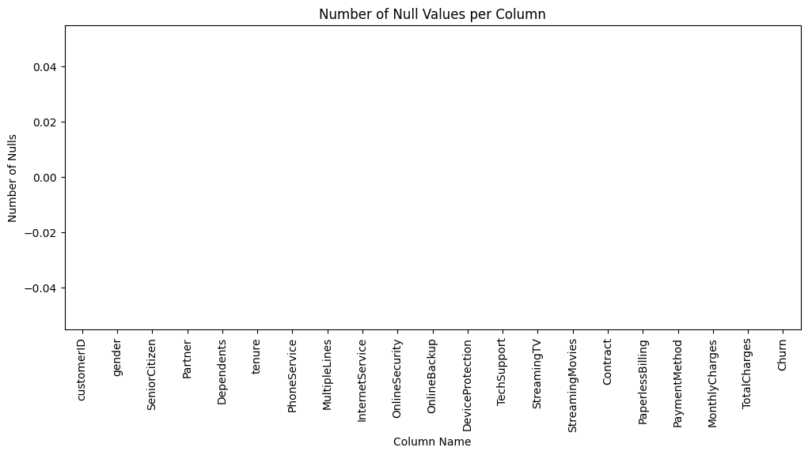

```python
data_null_counts = churn_data.isnull().sum()
plt.figure(figsize=(12,5))
data_null_counts.plot(kind="bar")
plt.title("Number of Null Values per Column")
plt.xlabel("Column Name")
plt.ylabel("Number of Nulls")
```

```python
churn_data['tenure'].unique()
```

```
array([ 1, 34,  2, 45,  8, 22, 10, 28, 62, 13, 16, 58, 49, 25, 69, 52, 71,
       21, 12, 30, 47, 72, 17, 27,  5, 46, 11, 70, 63, 43, 15, 60, 18, 66,
        9,  3, 31, 50, 64, 56,  7, 42, 35, 48, 29, 65, 38, 68, 32, 55, 37,
       36, 41,  6,  4, 33, 67, 23, 57, 61, 14, 20, 53, 40, 59, 24, 44, 19,
       54, 51, 26,  0, 39])
```

```python
churn_data['SeniorCitizen'] = churn_data['SeniorCitizen'].map({1: "Yes", 0: "No"})
```

```python
churn_data['Churn'].unique()
```

```
array(['No', 'Yes'], dtype=object)
```

```python
churn_data['']
```

### EDA

How many customers have churned?

The graph below shows the number of customers churned and those who did not. As the bar plot shows, the majority of customers within the database have not churned. However, we will investigate the data further to achieve insight into the factors that lead to these outcomes.

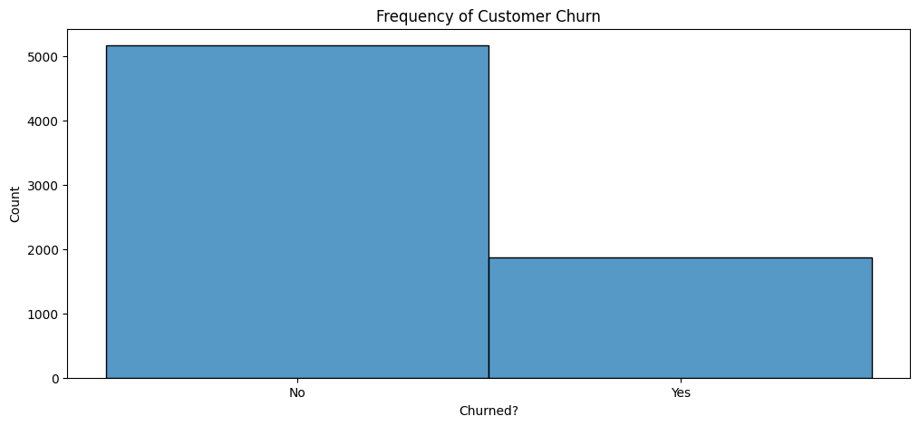

```python
plt.figure(figsize=(12,5))
sns.histplot(churn_data['Churn'])
plt.title("Frequency of Customer Churn")
plt.xlabel("Churned?")
plt.show()
```

Correlation of the features with pairplots.

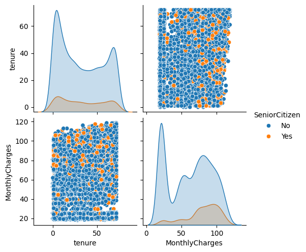

```python
sns.pairplot(churn_data, hue = 'SeniorCitizen')
```

No normal distributions here. It looks like there are less senior citizens in the data set. The larger ditribution of senior citizens pay larger sums of monthly charges.

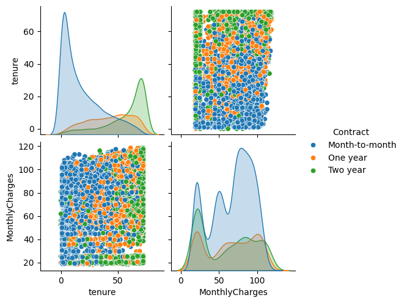

```python
sns.pairplot(churn_data, hue = 'Contract')
```

Customers with two-year contacts have longer tenure.

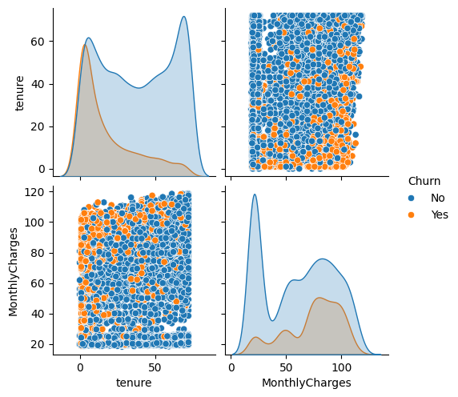

```python
sns.pairplot(churn_data, hue = 'Churn')
```

```python
churned = churn_data[churn_data['Churn'] == 'Yes']
not_chunred = churn_data[churn_data['Churn'] == 'No']

churned_tenure = churned.tenure
not_churned_tenure = not_chunred.tenure
```

Lets check to see the density of the tenure. This will allow us to see whether the data is normally distributed or not.

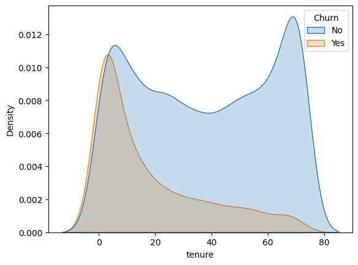

```python
sns.kdeplot(data=churn_data, x='tenure', hue='Churn', fill=True)
```

The graph above shows that the tenure data among churned and not churned groups is not normally distributed. The churned customers are normally distributed with a right skew.

The graph below depicts the number of churning and non-churning customers by tenure.

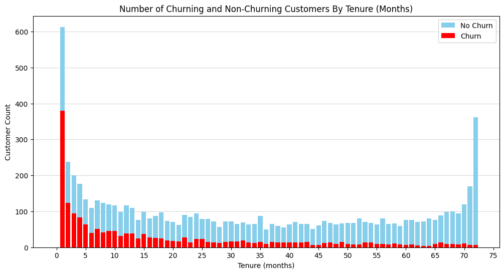

```python
tenure_counts = churn_data['tenure'].value_counts().sort_index()
churn_counts  = churn_data.loc[churn_data['Churn']=="Yes", 'tenure'].value_counts().sort_index()

no_churn_counts = tenure_counts - churn_counts




# align indices
tenure_counts, churn_counts = tenure_counts.align(churn_counts, fill_value=0)
rate = (churn_counts / tenure_counts)

fig, ax = plt.subplots(figsize=(12,6))
ax.bar(tenure_counts.index, no_churn_counts,bottom = churn_counts, label='No Churn', color = "skyblue")
ax.bar(tenure_counts.index, churn_counts, label='Churn', color='red')
ax.xaxis.set_major_locator(MultipleLocator(5))

plt.title("Number of Churning and Non-Churning Customers By Tenure (Months)")
plt.xlabel("Tenure (months)")
plt.ylabel("Customer Count")
ax.set_axisbelow(True)
plt.grid(axis = 'y', alpha = 0.5)
plt.legend()
plt.show()
```

The number of churning customers has a decreasing trend as the number of months with the company increases.

Let's look at churn rates (%) for each tenure.

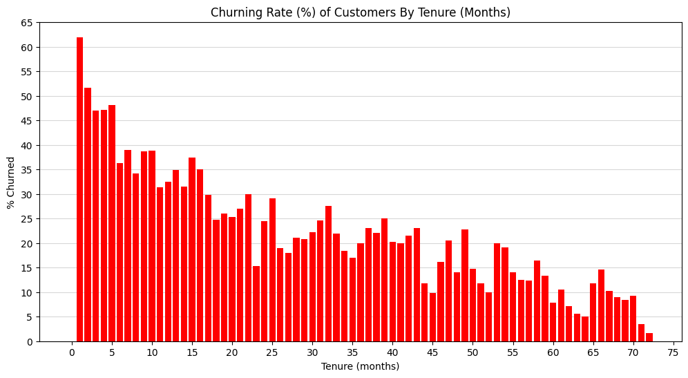

```python
churn_percentage = (churn_counts/tenure_counts)*100

fig, ax = plt.subplots(figsize=(12,6))
ax.bar(tenure_counts.index, churn_percentage, label='Churn', color='red')
ax.xaxis.set_major_locator(MultipleLocator(5))
ax.yaxis.set_major_locator(MultipleLocator(5))

plt.title("Churning Rate (%) of Customers By Tenure (Months)")
plt.xlabel("Tenure (months)")
plt.ylabel("% Churned")
ax.set_axisbelow(True)
plt.grid(axis = 'y', alpha = 0.5)

plt.show()
```

The highest churn rate (>60%) is amongst customers who have been with the company for only 1 month. This churn rate gradually decreases among the more loyal customers. A very low churn rate (<5%) exists among the most loyal customers who have been with the company for 72 months.

### Hypothesis Testing

#### Hypothesis #1

Maybe the age of the customers is a factor in whether they churn or not.

$ 𝐻_{0} $: Senior proportions are not significantly different between churning and non-churning customers.

$ 𝐻_{A} $: Senior proportions are different between churning and non-churning groups.

```python
contingency= pd.crosstab(churn_data.SeniorCitizen, churn_data.Churn)
contingency
```

| Churn SeniorCitizen | No | Yes |
| --- | --- | --- |
| No | 4508 | 1393 |
| Yes | 666 | 476 |

The bar graph below depicts the distribution of churn by senior status. This will allow us to compare the distribution of customers among the churn groups and senior status.

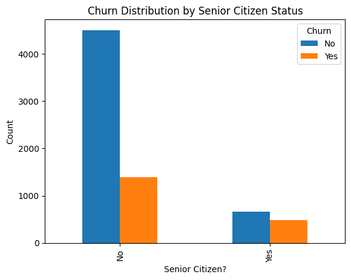

```python
contingency.plot(kind='bar')
plt.title("Churn Distribution by Senior Citizen Status")
plt.ylabel("Count")
plt.xlabel("Senior Citizen?")
```

The majority of customers are not senior citizens. In both groups, the number of those who have not churned are greater than those who have. Among senior citizens however, the number of churned and not churned are closer. A chi-squared hypothesis test will allow us to see if senior status is a significant factor in determining churn outcome.

```python
chi2, p_val, dof, exp_freq = chi2_contingency(contingency, correction = False)
print('chi-square statistic: {} , p_value: {} , degree of freedom: {} ,expected frequencies: {} '.format(chi2, p_val, dof, exp_freq))
```

```
chi-square statistic: 160.35213184520632 , p_value: 9.477903507376051e-37 , degree of freedom: 1 ,expected frequencies: [[4335.05239245 1565.94760755]
 [ 838.94760755  303.05239245]]
```

```python
if (p_val < 0.05):
    print('Reject the null hypothesis, that senior proportions are not significantly different between churning and non-churning customers.')
else:
    print('Accept the null hypothesis, that senior proportions are not significantly different between churning and non-churning customers.')
```

```
Reject the null hypothesis, that senior proportions are not significantly different between churning and non-churning customers.
```

Since we rejected the null hypothesis, we can conclude that there is an association between senior status and churn outcome.

#### Hypothesis #2

Perhaps the price of the services was the reason why our customers churned. It could be reasoned that the customers who churned were charged more than those who didn't. To thest this theory, the hypothesis testing below is carried out.

$ 𝐻_{0}:\mu_{1}<=\mu_{2} $ The average monthly charges of customers who churned are less than or equal to customers who didn't churn.

$ 𝐻_{A}:\mu_{1}>\mu_{2} $ The average monthly charges of customers who churned are greater than customers who didn't churn.

```python
churned = churn_data[churn_data['Churn'] == 'Yes']
churned_char = churned.MonthlyCharges
churned_char_mean = churned_char.mean()
churned_char_mean
```

```
np.float64(74.44133226324237)
```

```python
not_churned = churn_data[churn_data['Churn'] == 'No']
not_churned_char = not_churned.MonthlyCharges
not_churned_char_mean = not_churned_char.mean()
not_churned_char_mean
```

```
np.float64(61.26512369540008)
```

Box plot to show distribution of monthly charges by churn outcome.

```
[Text(0.5, 1.0, 'Monthly Charges Distribution by Churn Outcome')]
```

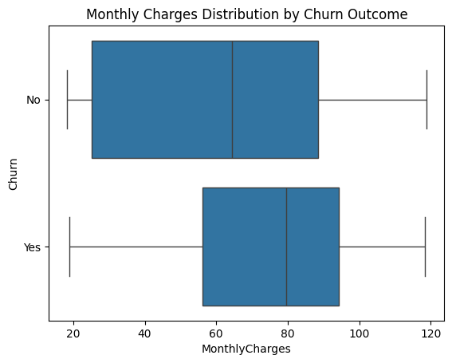

```python
sns.boxplot(x=churn_data.MonthlyCharges,y=churn_data.Churn,data=churn_data).set(title="Monthly Charges Distribution by Churn Outcome")
```

The median monthly charges of churning customers is greater than the median monthly charges of not churning customers. Additionally, there is wider spread of charges for non churning customers.

```python
alpha = 0.05
t_val2, p_value2 = stats.ttest_ind(churned_char, not_churned_char)
p_value_onetail=p_value2/2
print("t_value = {} , p_value ={} , p_value_onetail = {}".format(t_val2, p_value2, p_value_onetail))
```

```
t_value = 16.536738015936308 , p_value =2.7066456068884154e-60 , p_value_onetail = 1.3533228034442077e-60
```

```python
# Enter your code and run the cell
if p_value_onetail <alpha:
    print("Conclusion: since p_value {} is less than alpha {} ".format(p_value_onetail, alpha))
    print("Reject the null hypothesis that the average monthly charges of customers who churned are less than or equal to customers who didn't churn.")

else:
    print("Conclusion: since p_value {} is greater than alpha {} ".format(p_value_onetail, alpha))
    print("Fail to reject the null hypothesis that the average monthly charges of customers who churned are less than or equal to customers who didn't churn.")
```

```
Conclusion: since p_value 1.3533228034442077e-60 is less than alpha 0.05
Reject the null hypothesis that the average monthly charges of customers who churned are less than or equal to customers who didn't churn.
```

Since we reject the null hypthesis, we can conclude that the average monthly charges of customers who churned are greater than those who didn't churn. Therefore, pricing can be a factor that leads to customer churn. This may lead to a reconsideration of pricing or further investigation into why the churning individuals were being charged at higher prices.

#### Hypothesis #3

Could the contract type have an effect on churn outcome? This will be worth investigating to see whether the company should change its contract policies or not.

$ 𝐻_{0} $: The proportion of churning customers are not significantly different across the different contract types.

$ 𝐻_{A} $: Churning customer proportions are significantly different across contract types.

```python
contingency= pd.crosstab(churn_data.Contract, churn_data.Churn)
contingency
```

| Churn Contract | No | Yes |
| --- | --- | --- |
| Month-to-month | 2220 | 1655 |
| One year | 1307 | 166 |
| Two year | 1647 | 48 |

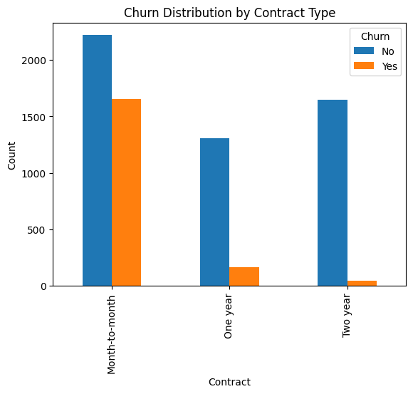

```python
contingency.plot(kind='bar')
plt.title("Churn Distribution by Contract Type")
plt.ylabel("Count")
plt.xlabel("Contract")
```

```python
chi2, p_val, dof, exp_freq = chi2_contingency(contingency, correction = False)
print('chi-square statistic: {} , p_value: {} , degree of freedom: {} ,expected frequencies: {} '.format(chi2, p_val, dof, exp_freq))
```

```
chi-square statistic: 1184.5965720837926 , p_value: 5.863038300673391e-258 , degree of freedom: 2 ,expected frequencies: [[2846.69175067 1028.30824933]
 [1082.11018032  390.88981968]
 [1245.198069    449.801931  ]]
```

```python
if (p_val < 0.05):
    print('Reject the null hypothesis, that churning proportions are not different across contract types.')
else:
    print('Accept the null hypothesis, that churning proportions are not different across contract types.')
```

[output not shown]

Since we reject the null hypothesis, we can conclude that churning customer proportions are significantly different across contract types.

### Conclusion

#### The Data

The Telco Customer Churn is a subset from a larger IBM dataset and was analyzed for EDA and hypothesis testing. The dataset contains customer information and their churn outcome.

#### What We Found

No missing values were found, being indicative that the data may have been already cleaned or was collected well. The majority of customers in the dataset have not churned. The highest rate of churn appears in customers who have been with the company for only 1 month.

Through chi-squared hypothesis testing, we found that the senior status of customers affects the churn outcome, as there is a siginificant difference in proportion in churn outcome by senior status. Additionally, a t-test showed that the average monthly charges of customers who churned were greater than those who did not. This means that cost is a significant factor in churn outcome. Lastly, the proportion of churning and not churning customers are significantly different across contract types, as was discovered via chi-squared testing.

#### Next Steps

More hypothesis tests can be done with the rest of the categorical variables available, to see if they are also significant factors in churn outcome. Multivariate tests may also be done. A more comprehensive dataset that contains more features may help with factors such as exact age and geographical location.

With logistic regression, we can find out what threshold of monthly cost can make the difference between a customer who will churn and one who won't. It would also be worth finding out how long it will take for a customer to be with the company to make them less likely to churn.